# Unveiling Structural Linear Dependencies Of Handwritten Digits

### Figure 18

```
Reconstruction of digit 7
Test Set R^2 Score (Left/Right): 0.2922
Test Set R^2 Score (Top/Bottom): 0.1454
Visualizing Test Sample Index: 38
```

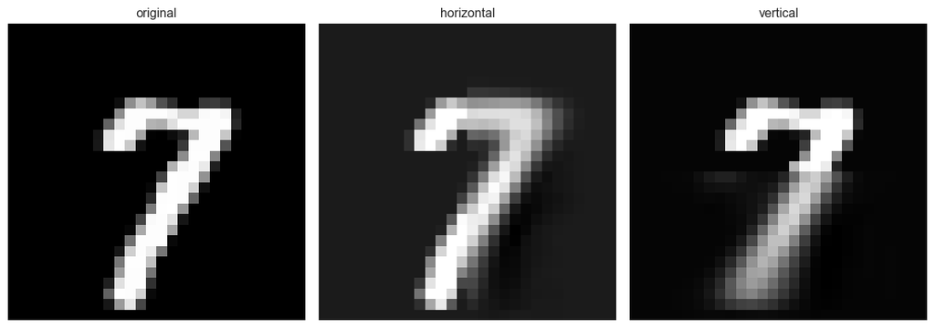

```
Reconstruction of digit 7
Test Set R^2 Score (Left/Right): 0.3935
Test Set R^2 Score (Top/Bottom): 0.2257
Visualizing Test Sample Index: 3
```

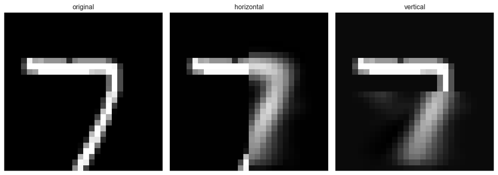

```
Reconstruction of digit 4
Test Set R^2 Score (Left/Right): 0.1031
Test Set R^2 Score (Top/Bottom): 0.1372
Visualizing Test Sample Index: 36
```

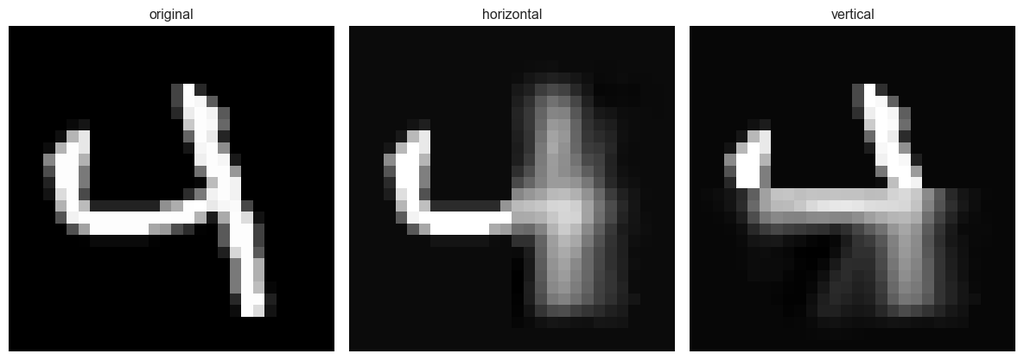

```
Reconstruction of digit 4
Test Set R^2 Score (Left/Right): 0.1445
Test Set R^2 Score (Top/Bottom): 0.0542
Visualizing Test Sample Index: 16
```

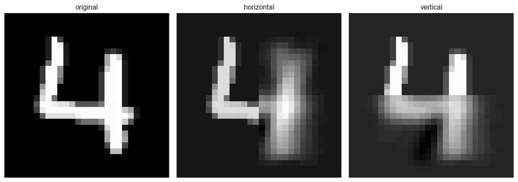

```python
# Figure 18
run_hd_reconstruction_demo(X, y, target_digit=7)
run_hd_reconstruction_demo(X, y, target_digit=7)
run_hd_reconstruction_demo(X, y, target_digit=4)
run_hd_reconstruction_demo(X, y, target_digit=4)
```

### Figure 19

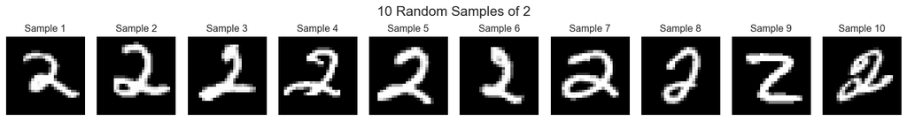

```python
# Figure 19
display_10samples_number(target_digit=2)
```

### Figure 20

```
 CCA Weight Barplot - Digit 2, Mode LR
Dominant PC in Left: PC3 (Weight: 0.7489)
```

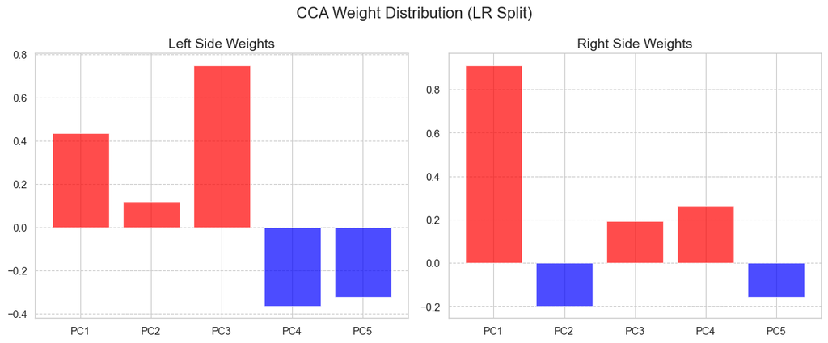

```
 CCA Weight Barplot - Digit 2, Mode TB
Dominant PC in Top: PC1 (Weight: 0.9545)
```

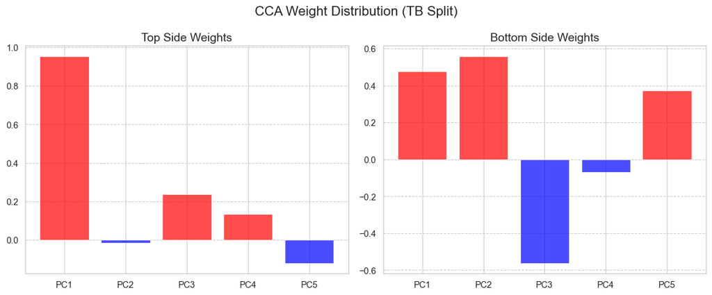

```python
# Figure 20
inspect_cca_weights_unified(X, y, target_digit=2, n_components=5, mode='LR')
inspect_cca_weights_unified(X, y, target_digit=2, n_components=5, mode='TB')
```

### Figure 21:

#### figure 21 is extracted and merged into one figure from figure 5 and figure 8. See the 2 inside.

```python
# Figure 21:
print("figure 21 is extracted and merged into one figure from figure 5 and figure 8. See the 2 inside.")
```

```
figure 21 is extracted and merged into one figure from figure 5 and figure 8. See the 2 inside.
```

### Figure 22

```
Reconstruction of digit 2
Test Set R^2 Score (Left/Right): 0.2980
Test Set R^2 Score (Top/Bottom): 0.1761
Visualizing Test Sample Index: 11
```

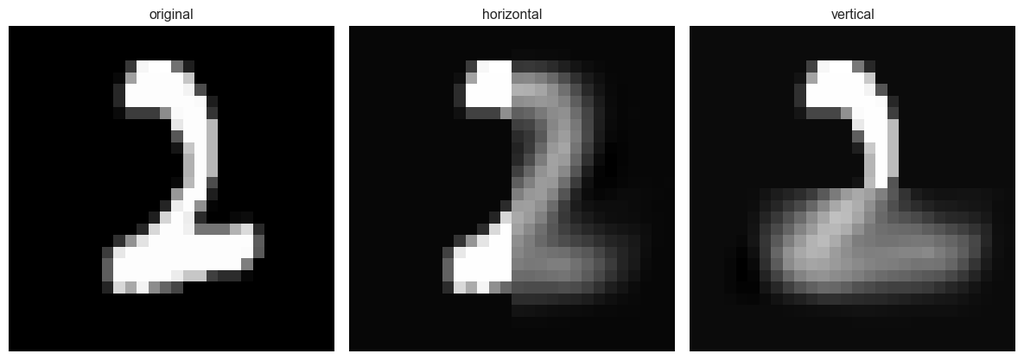

```
Reconstruction of digit 2
Test Set R^2 Score (Left/Right): -0.0009
Test Set R^2 Score (Top/Bottom): 0.0784
Visualizing Test Sample Index: 26
```

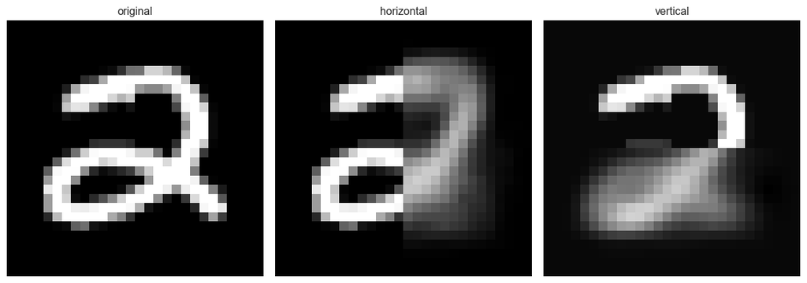

```
Reconstruction of digit 2
Test Set R^2 Score (Left/Right): 0.2496
Test Set R^2 Score (Top/Bottom): 0.1893
Visualizing Test Sample Index: 13
```

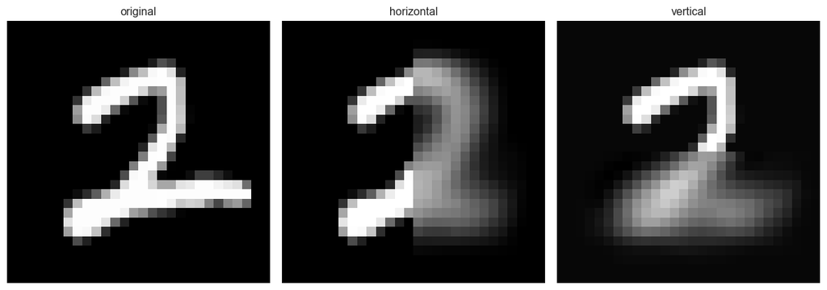

```
Reconstruction of digit 2
Test Set R^2 Score (Left/Right): 0.1612
Test Set R^2 Score (Top/Bottom): 0.1482
Visualizing Test Sample Index: 23
```

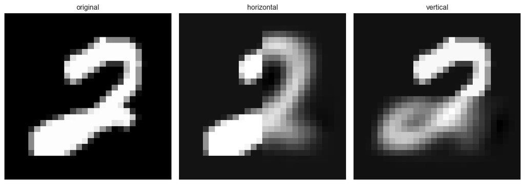

```python
# Figure 22: the heatmap is extracted from figure 5, both LR and TB mode.
run_hd_reconstruction_demo(X, y, target_digit=2)
run_hd_reconstruction_demo(X, y, target_digit=2)
run_hd_reconstruction_demo(X, y, target_digit=2)
run_hd_reconstruction_demo(X, y, target_digit=2)
```

# Documentations

1. get_image_splits(X_input, mode='LR', img_size=28):

   Image splitting logic:

   mode: 'LR' - Left / Right Split mode: 'TB' - Top / Bottom Split mode: '4way' - Top Bottom / Left / Right Split all together
2. compute_pca_cca_pipeline(X1, X2, n_components):

   PCA -> CCA Algorithm n_components: number of components X1: one side of image of a given dividing algorithm X2: other side of image of the same dividing algorithm as X1
3. visualize_cca_geometry(X, y, n_components, mode='LR'):

   Run CCA visualizations based on the mode selected.

   mode: 'LR' - Left / Right Split mode: 'TB' - Top / Bottom Split mode: '4way' - Top Bottom / Left / Right Split all together
4. verify_variance_coverage(X, y, n_components):

   Verifying the variance explained by n_components PCAs. Normally, this number is set to 5. In my essay, it's set to 20 and 5, to demonstrate that the image data is highly redundant and showing that around 50% of the variance could be explained by first 5 PCs, and around 80% of the variance could be explained by first 20 PCs.
5. inspect_cca_weights_unified(X, y, target_digit, n_components, mode='TB'):

   this function will implement the weight of CCA of a given segment of picture by visualizing them in barplot.

   this function will implement the weight of CCA of top/bottom of a digit, output will be in table. the result of figure visual representation aligns with the numeric value. This is not used in the demonstration of essay.

   normally, only 5 PCs will be displayed unless otherwise defined.
7. visualize_pc_matrix_unified(X, y, target_digit, n_components):

   this function will use Top/Bottom/Left/Right split of a given digit. After calculated their first n_components, normally 5, it will visualize their PC transformed data into heatmap.
8. def plot_4way_scree(X, n_components):

   plotting Top/Bottom/Left/Right PCA Scree Plot to be used in the analysis of variance explained.
9. display_top_bottom_split(X, y, target_digit):

   This function displays target_digit's top and bottom split image of the raw, normalized data.
10. run_hd_reconstruction_demo(X, y, n_components=5, target_digit=None):

    This function trains a linear regression model as well as the PCA algorithm.

    The image data is first partitoned, and top or left side will be splited into training and testing dataset in 9:1, which here is 450 and 50.

    The PCs are then computed by using the training data, then desired number of PCs(normally 5)will be used to reduce the dimension of testing dataset. Then a linear regression model is fitted based on least squares.

    Testing dataset is used to verify our conclusion in the essay. An R^2 score will also be outputed as reference.

    Linear regression's output will be restored into format of half of image. They will then be merged together into a full image to compare with the selected original testing data.

    As stated in the methology part, this linear regression's purpose is showing difference instead of precisely restoring the image, the R^2 score is usually low. I use visual difference to claim my hypothesis instead of this R^2 output as it also can not show the "preference denepdencies" of up/down and left/right division, but it is also used for me to further verify my assumptions.
11. display_10samples_number(target_digit):

    Select 10 Random Sample of the Given Number and display their image.
12. plot_correlation_summary_bars(X, y, n_components):

    calculate and fit barplot of CCA correlation of all digits in horizontal and vertical splits
13. visualize_digit_pc1_only(X, y, target_digit, n_components):

    this function only visualize the target_digit's PC1 of four splits.

**Generative AI Usage Notification**:

In the coding, Google Gemini 3 Pro was used for debugging, providing coding suggestions and help merging/cleaning redundant variables. However, the core algorithm of coding itself, implementations, documentations, structure and research process, writing of comments and so on are done individually by me(Zixiang Zhang). The essay and its intepretations are also written individually by me(Zixiang Zhang).